# Отчет по лабораторной работе №7

Расширенные настройки межсетевого экрана

Виноградова М.А

Российский университет дружбы народов, Москва, Россия

17 октября 2026

# Информация

## Докладчик

- Виноградова Мария Андреевна
- студентка НПИбд-02-24
- номер студ. билета 1132240691
- Российский университет дружбы народов
- 1132240691@rudn.ru
- https://github.com/mavinogradova/study_2026-2027

# Цель работы

Получить навыки настройки межсетевого экрана в Linux в части переадресации портов и настройки Masquerading.

# Задание

1. Настройте межсетевой экран виртуальной машины server для доступа к серверу по протоколу SSH не через 22-й порт, а через порт 2022 (см. разделы 7.4.1 и 7.4.2).
2. Настройте Port Forwarding на виртуальной машине server (см. разделы 7.4.3).
3. Настройте маскарадинг на виртуальной машине server для организации доступа клиента к сети Интернет (см. раздел 7.4.3).
4. Напишите скрипт для Vagrant, фиксирующий действия по расширенной настройке межсетевого экрана. Соответствующим образом внести изменения в Vagrantfile (см. раздел 7.4.4).

# Выполнение лабораторной работы

## Создание службы firewall. Вход на server

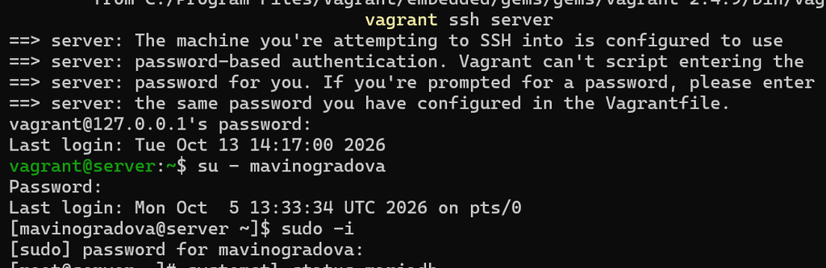

Вход на виртуальную машину server под пользователем mavinogradova и переход в режим суперпользователя

## Создание службы firewall. Копирование ssh.xml

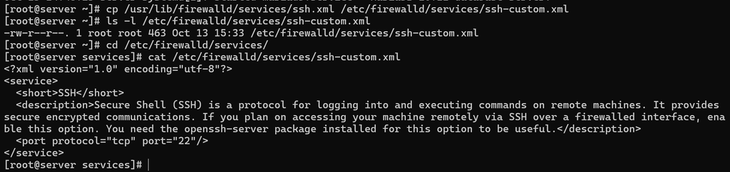

Создание файла ssh-custom.xml и просмотр его исходного содержимого

## Создание службы firewall. Редактирование ssh-custom.xml

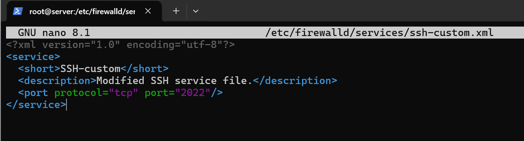

Редактирование файла ssh-custom.xml: изменённый порт 2022 и модифицированное описание

## Создание службы firewall. Список служб до и после reload

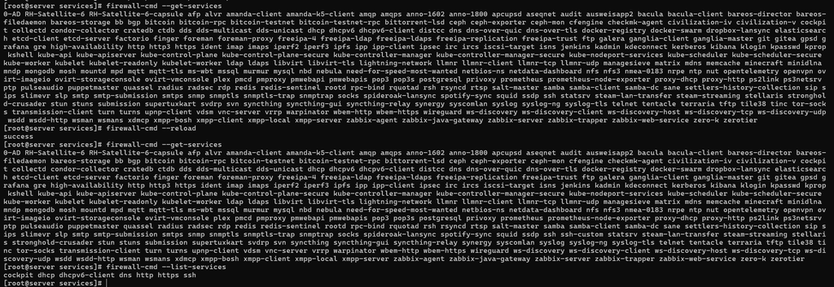

Просмотр списка служб FirewallD до и после перезагрузки правил

## Создание службы firewall. Добавление ssh-custom

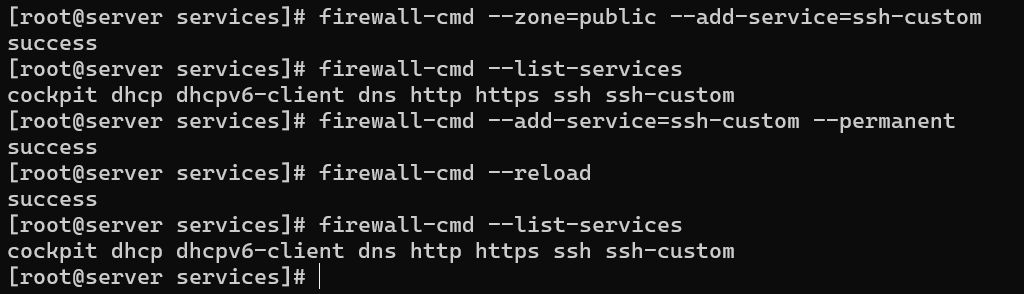

Добавление службы ssh-custom в FirewallD и проверка списка активных служб

## Перенаправление портов. Организация проброса

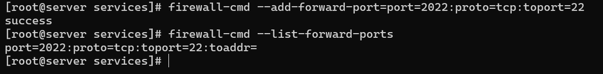

Организация переадресации с порта 2022 на порт 22 и проверка правила

## Перенаправление портов. Проверка с клиента

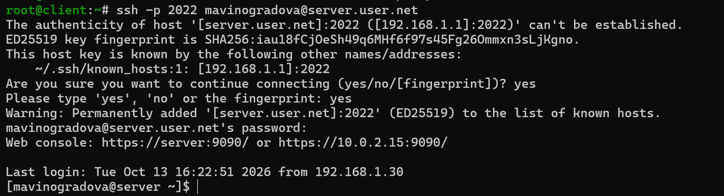

Подключение к серверу по SSH через порт 2022 с клиента

## NAT. Проверка ip_forward

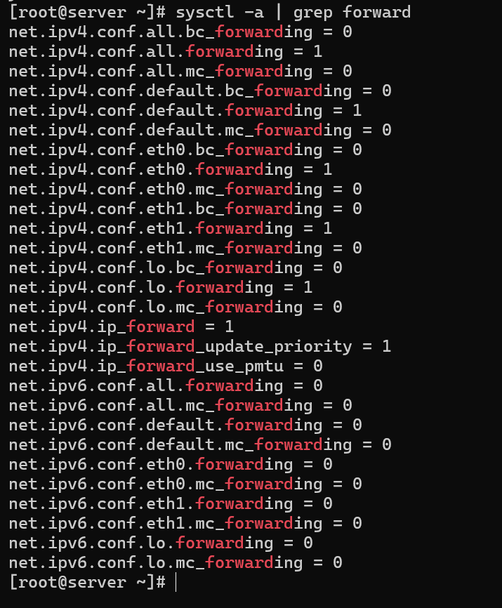

Проверка активации перенаправления IPv4-пакетов в ядре

## NAT. Включение ip_forward

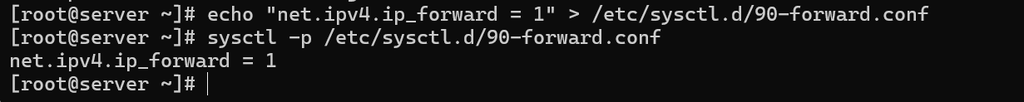

Включение перенаправления IPv4-пакетов на сервере

## Masquerading. Включение

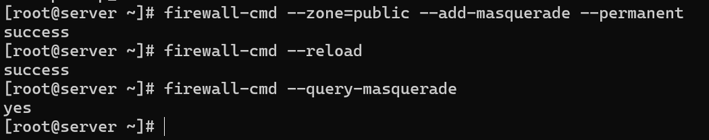

Включение маскарадинга на сервере и проверка статуса

## Masquerading. Проверка с клиента

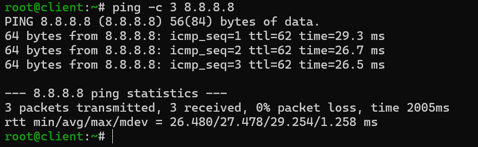

Проверка доступности выхода в Интернет на клиенте

## Окружение ВМ. Копирование файлов

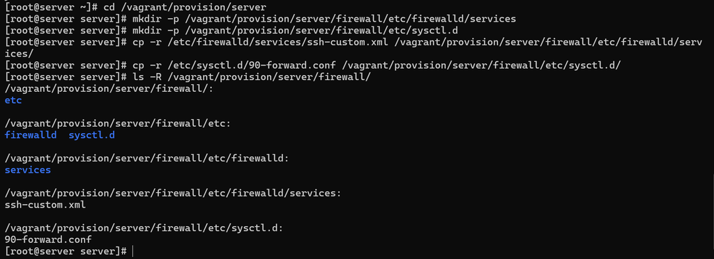

Создание каталога firewall и копирование конфигурационных файлов в каталог провижининга

## Окружение ВМ. Создание firewall.sh

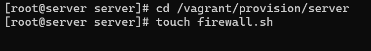

Создание исполняемого файла firewall.sh

## Окружение ВМ. Содержимое firewall.sh

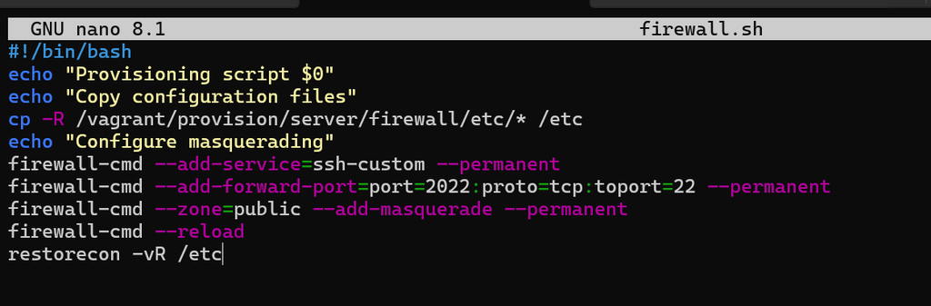

Содержимое скрипта провижининга firewall.sh

## Окружение ВМ. Правка Vagrantfile

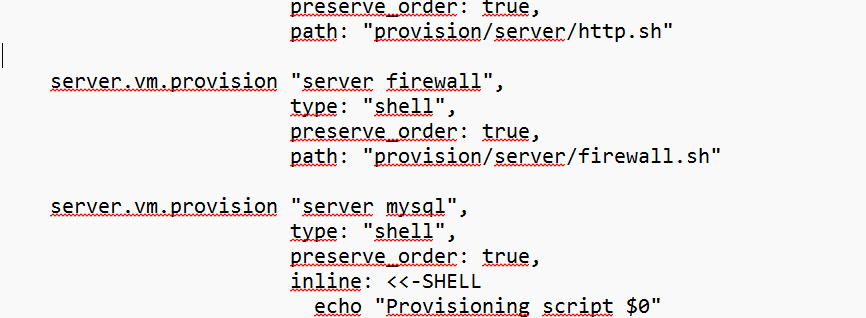

Фрагмент Vagrantfile с добавленным блоком провижининга server firewall

# Выводы

В ходе лабораторной работы были получены навыки настройки межсетевого экрана в Linux в части переадресации портов и настройки Masquerading. Создана пользовательская служба FirewallD `ssh-custom` с портом 2022 на основе существующего описания службы ssh, служба успешно добавлена в FirewallD. Организована переадресация с порта 2022 на порт 22, проверено SSH-подключение к серверу через порт 2022 с клиента. Включено перенаправление IPv4-пакетов в ядре и маскарадинг в зоне public, проверен выход клиента в сеть Интернет. Написан скрипт провижининга `firewall.sh`, автоматизирующий расширенную настройку межсетевого экрана, и внесены соответствующие изменения в `Vagrantfile`.